# Comparando mecanismos para jukebox sociais

```r
dados = read_csv(here::here("data/satisfacoes.csv"),
                 col_types = "cdcc")

glimpse(dados)
```

```
## Rows: 115
## Columns: 4
## $ user_id      <chr> "1", "2", "3", "4", "5", "6", "7", "8", "9", "10", "11", ~
## $ satisfaction <dbl> 2.0, 3.0, 1.5, 1.0, 2.0, 2.5, 2.0, 3.0, 2.0, 2.0, 2.0, 2.~
## $ scenario     <chr> "baseline", "baseline", "baseline", "baseline", "baseline~
## $ group        <chr> "3", "1", "2", "2", "1", "1", "3", "3", "2", "1", "3", "2~
```

## Utilizando Intervalos de Confiança

Inicialmente vamos calcular o intervalo de confiança para a média cada um dos mecanismos, de maneira a identificar qual mecanismo teve o melhor desempenho. Os ICs serão calculados realizando o bootstrap por meio da biblioteca boot.

### Calculando a média de cada mecanismo

```r
theta <- function(d, i) {
    agrupado = d %>%
        slice(i) %>%
        group_by(scenario) %>%
        summarise(media = mean(satisfaction))
    baseline = agrupado %>% filter(scenario == "baseline") %>% pull(media)
    l_d = agrupado %>% filter(scenario == "like/dislike") %>% pull(media)
    skip = agrupado %>% filter(scenario == "skip") %>% pull(media)
    u_d = agrupado %>% filter(scenario == "up/downvoting") %>% pull(media)
    combined = agrupado %>% filter(scenario == "combined") %>% pull(media)
    c(baseline, l_d, skip, u_d, combined)
}

medias <- data.frame("Mecanismo" = c("Baseline", "Like/Dislike", "Skip", "Up/downvoting", "Combined"), "theta" = theta(dados, i = 1:NROW(dados)))

medias
```

```
##       Mecanismo    theta
## 1      Baseline 2.130435
## 2  Like/Dislike 3.652174
## 3          Skip 2.521739
## 4 Up/downvoting 4.391304
## 5      Combined 4.043478
```

### Calculando e apresentando os intervalos de confiança de cada mecanismo

```r
cis = boot(data = dados,
           statistic = theta,
           R = 2000) %>%
    tidy(conf.level = .95,
         conf.method = "bca",
         conf.int = TRUE)

cis$scenario = c("baseline", "like/dislike", "skip", "up/downvoting", "combined")
cis
```

```
## # A tibble: 5 x 6
##   statistic     bias std.error conf.low conf.high scenario
##       <dbl>    <dbl>     <dbl>    <dbl>     <dbl> <chr>
## 1      2.13 -0.00129    0.135      1.86      2.39 baseline
## 2      3.65 -0.00354    0.114      3.43      3.88 like/dislike
## 3      2.52 -0.00305    0.109      2.30      2.72 skip
## 4      4.39 -0.00187    0.0920     4.22      4.58 up/downvoting
## 5      4.04 -0.00288    0.111      3.82      4.27 combined
```

Sumarizando o que é apresentado acima, temos:

1. A média para o mecanismo **baseline** é de 2.130435 com IC aproximado de [1.86, 2.39].

2. A média para o mecanismo **like/dislike** é de 3.652174 com IC aproximado de [3.43, 3.89].

3. A média para o mecanismo **skip** é de 2.521739 com IC aproximado de [2.30, 2.73].

Podemos ainda plotar o gráfico de maneira a obter uma visualização dos intervalos de confiança de cada mecanismo.

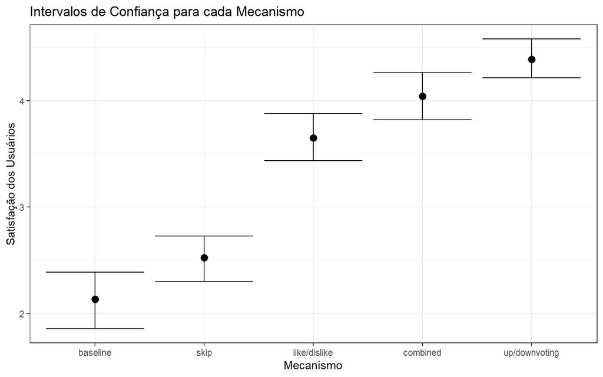

```r
cis %>%
    ggplot(aes(
        x = reorder(scenario, statistic),
        y = statistic,
        ymin = conf.low,
        ymax = conf.high
    )) +
    geom_pointrange() +
    geom_errorbar(aes(ymax = conf.high, ymin = conf.low)) +
    geom_point(size = 3) +
    labs(title = "Intervalos de Confiança para cada Mecanismo", x = "Mecanismo",
         y = "Satisfação dos Usuários")
```

De acordo com o apresentado, podemos observar que aparentemente os mecanismos **up/downvoting**, **combined** e **like/dislike** foram os melhores avaliados, no entanto é possível observar que existe sobreposição nos intervalos desses três mecanismos. Assim, se torna interessante estimar qual desses é o melhor por meio da diferença utilizandos os intervalos de confiança. Vamos analisar a diferença entre o mecanismo que obteve o melhor desempenho aparente, **up/downvoting**, e os outros mecanismos, com foco no **combined** e no **like/dislike**.

### Calculando a diferença das médias entre up/downvoting e os demais mecanismos

```r
theta <- function(d, i) {
    agrupado = d %>%
        slice(i) %>%
        group_by(scenario) %>%
        summarise(media = mean(satisfaction))
    baseline = agrupado %>% filter(scenario == "baseline") %>% pull(media)
    l_d = agrupado %>% filter(scenario == "like/dislike") %>% pull(media)
    skip = agrupado %>% filter(scenario == "skip") %>% pull(media)
    u_d = agrupado %>% filter(scenario == "up/downvoting") %>% pull(media)
    combined = agrupado %>% filter(scenario == "combined") %>% pull(media)
    c(u_d - baseline, u_d - l_d, u_d - skip, u_d - combined)
}

dif_medias <- data.frame("Diferença das médias" = c("up/downvoting - baseline", "up/downvoting - like/dislike",
                        "up/downvoting - skip", "up/downvoting - combined"), "theta_chapeu" = theta(dados, i = 1:NROW(dados)))

dif_medias
```

```
##           Diferença.das.médias theta_chapeu
## 1     up/downvoting - baseline    2.2608696
## 2 up/downvoting - like/dislike    0.7391304
## 3         up/downvoting - skip    1.8695652
## 4     up/downvoting - combined    0.3478261
```

### Calculando e apresentando os intervalos de confiança

```r
cis = boot(data = dados,
           statistic = theta,
           R = 2000) %>%
    tidy(conf.level = .95,
         conf.method = "bca",
         conf.int = TRUE)

cis$scenario = c("up/downvoting - baseline", "up/downvoting - like/dislike", "up/downvoting - skip", "up/downvoting - combined")
cis
```

```
## # A tibble: 4 x 6
##   statistic     bias std.error conf.low conf.high scenario
##       <dbl>    <dbl>     <dbl>    <dbl>     <dbl> <chr>
## 1     2.26  -0.00315     0.161   1.95       2.58  up/downvoting - baseline
## 2     0.739 -0.00465     0.149   0.450      1.03  up/downvoting - like/dislike
## 3     1.87  -0.00318     0.142   1.60       2.14  up/downvoting - skip
## 4     0.348  0.00341     0.150   0.0668     0.662 up/downvoting - combined
```

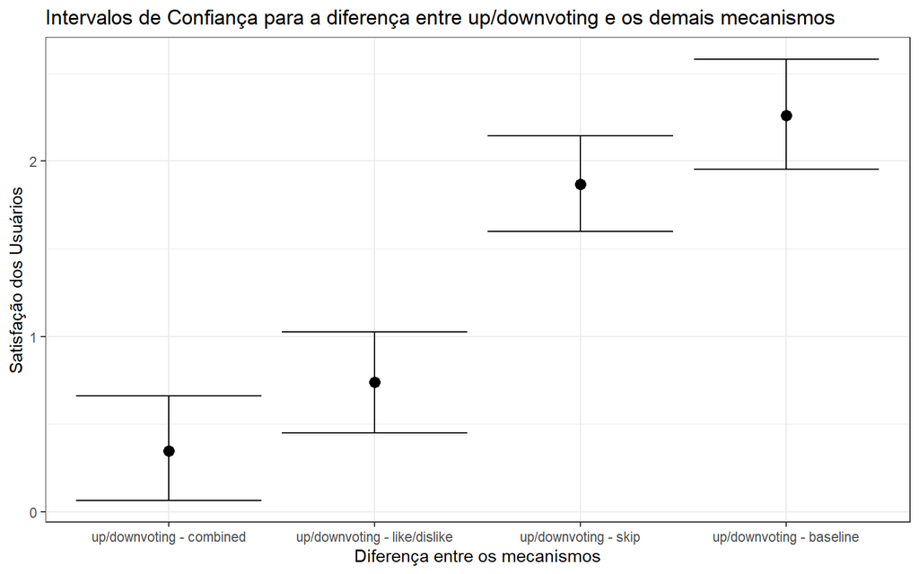

```r
cis %>%
    ggplot(aes(
        x = reorder(scenario, statistic),
        y = statistic,
        ymin = conf.low,
        ymax = conf.high
    )) +
    geom_pointrange() +
    geom_errorbar(aes(ymax = conf.high, ymin = conf.low)) +
    geom_point(size = 3) +
    labs(title = "Intervalos de Confiança para a diferença entre up/downvoting e os demais mecanismos", x = "Diferença entre os mecanismos",
         y = "Satisfação dos Usuários")
```

A partir dos cálculos dos intervalos de confiança tomando a diferença entre o **up/downvoting** e os demais mecanismos, podemos observar que a diferença entre o **up/downvoting** e o **combined** é bem pequena, e como a média deste primeiro mecanismo foi maior, podemos afirmar com 95% de confiança que este é melhor e mais bem avaliado que o **combined**. Podemos ver também que o **skip** e o **baseline** tiveram uma diferença bem mais significativa, o que dentro das opções, descarta estes de serem os melhores mecanismos. Por fim, a diferença para o **like/dislike** ainda se mostra sobrepondo a diferença que apresenta o menor intervalo, porém a média da diferença para este mecanismo ainda é maior e se aproxima mais de 1 (0.739), assim ainda podemos afirmar, utilizando intervalos de confiança, que o mecanismo **up/downvoting** é o melhor.

## Utilizando Teste de Hipótese Manual

De maneira similar ao que foi realizado utilizando intervalos de confiança, agora utilizar teste de hipótese para estimar a diferença entre o mecanismo que apresentou o melhor desempenho anteriormente, o **up/downvoting**, e os demais mecanismos (combined, like/dislike, skip e baseline). Será calculado o **theta_chapeu**, que representa a diferença das médias dos mecanismos e realizada a reamostragem (gerando 4000 reamostras) para verificar as diferenças dos dados da população através do **theta_emb** de cada comparação. Nesse caso, a H0 (hipótese nula) é se a diferença das médias da sastifação entre os mecanismos não corresponde ao valor do **theta_chapeu** e a H1 (hipótese alternativa) é se a diferença das médias da satisfação entre os mecanismos corresponde ao valor de **theta_chapeu**.

```r
theta_chapeu = {
    satisfacoes = dados %>%
        group_by(scenario) %>%
        summarise(satisfacao = mean(satisfaction))

    baseline = satisfacoes %>% filter(scenario == "baseline") %>% pull(satisfacao)
    l_d = satisfacoes %>% filter(scenario == "like/dislike") %>% pull(satisfacao)
    skip = satisfacoes %>% filter(scenario == "skip") %>% pull(satisfacao)
    u_d = satisfacoes %>% filter(scenario == "up/downvoting") %>% pull(satisfacao)
    combined = satisfacoes %>% filter(scenario == "combined") %>% pull(satisfacao)
    c(u_d - baseline, u_d - l_d, u_d - skip, u_d - combined)

}

thetas_chapeus <- data.frame("Diferença calculada" = c("up/downvoting - baseline", "up/downvoting - like/dislike",
                                              "up/downvoting - skip", "up/downvoting - combined"), "theta_chapeu" = theta_chapeu)

thetas_chapeus
```

```
##            Diferença.calculada theta_chapeu
## 1     up/downvoting - baseline    2.2608696
## 2 up/downvoting - like/dislike    0.7391304
## 3         up/downvoting - skip    1.8695652
## 4     up/downvoting - combined    0.3478261
```

### Reamostragem

Considerando 4000 reamostras da amostra original, a reamostragem é calculada utilizando as comparações entre o mecanismo up/downvoting** e os demais (**baseline**, **like/dislike**, **skip** e **combined** nessa ordem).

```r
theta_emb1 = function(d){
    satisfacoes = d %>%
        mutate(scenario_embaralhado = sample(scenario, n())) %>%
        group_by(scenario_embaralhado) %>%
        summarise(satisfacao = mean(satisfaction))

    u_d = satisfacoes %>% filter(scenario_embaralhado == "up/downvoting") %>% pull(satisfacao)
    baseline = satisfacoes %>% filter(scenario_embaralhado == "baseline") %>% pull(satisfacao)

    u_d - baseline
}

theta_emb2 = function(d){
    satisfacoes = d %>%
        mutate(scenario_embaralhado = sample(scenario, n())) %>%
        group_by(scenario_embaralhado) %>%
        summarise(satisfacao = mean(satisfaction))

    u_d = satisfacoes %>% filter(scenario_embaralhado == "up/downvoting") %>% pull(satisfacao)
    l_d = satisfacoes %>% filter(scenario_embaralhado == "like/dislike") %>% pull(satisfacao)

    u_d - l_d
}

theta_emb3 = function(d){
    satisfacoes = d %>%
        mutate(scenario_embaralhado = sample(scenario, n())) %>%
        group_by(scenario_embaralhado) %>%
        summarise(satisfacao = mean(satisfaction))

    u_d = satisfacoes %>% filter(scenario_embaralhado == "up/downvoting") %>% pull(satisfacao)
    skip = satisfacoes %>% filter(scenario_embaralhado == "skip") %>% pull(satisfacao)

    u_d - skip
}

theta_emb4 = function(d){
    satisfacoes = d %>%
        mutate(scenario_embaralhado = sample(scenario, n())) %>%
        group_by(scenario_embaralhado) %>%
        summarise(satisfacao = mean(satisfaction))

    u_d = satisfacoes %>% filter(scenario_embaralhado == "up/downvoting") %>% pull(satisfacao)
    combined = satisfacoes %>% filter(scenario_embaralhado == "combined") %>% pull(satisfacao)

    u_d - combined
}
```

```r
diffs_emb1 = replicate(4000, {theta_emb1(dados)})
diffs_emb2 = replicate(4000, {theta_emb2(dados)})
diffs_emb3 = replicate(4000, {theta_emb3(dados)})
diffs_emb4 = replicate(4000, {theta_emb4(dados)})
```

### Analisando os Testes

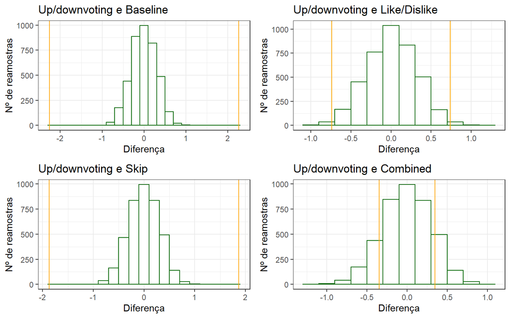

```r
up_base <- tibble(diferenca = diffs_emb1) %>%
    ggplot(aes(x = diferenca)) +
    geom_histogram(binwidth = .2, fill = "white", color = "darkgreen") +
    geom_vline(xintercept = theta_chapeu[1], color = "orange") +
    geom_vline(xintercept = -theta_chapeu[1], color = "orange") +
    labs(title = "Up/downvoting e Baseline", x = "Diferença", y = "Nº de reamostras")


up_like <- tibble(diferenca = diffs_emb2) %>%
    ggplot(aes(x = diferenca)) +
    geom_histogram(binwidth = .2, fill = "white", color = "darkgreen") +
    geom_vline(xintercept = theta_chapeu[2], color = "orange") +
    geom_vline(xintercept = -theta_chapeu[2], color = "orange") +
    labs(title = "Up/downvoting e Like/Dislike", x = "Diferença", y = "Nº de reamostras")

up_skip <- tibble(diferenca = diffs_emb3) %>%
    ggplot(aes(x = diferenca)) +
    geom_histogram(binwidth = .2, fill = "white", color = "darkgreen") +
    geom_vline(xintercept = theta_chapeu[3], color = "orange") +
    geom_vline(xintercept = -theta_chapeu[3], color = "orange") +
    labs(title = "Up/downvoting e Skip", x = "Diferença", y = "Nº de reamostras")

up_combined <- tibble(diferenca = diffs_emb4) %>%
    ggplot(aes(x = diferenca)) +
    geom_histogram(binwidth = .2, fill = "white", color = "darkgreen") +
    geom_vline(xintercept = theta_chapeu[4], color = "orange") +
    geom_vline(xintercept = -theta_chapeu[4], color = "orange") +
    labs(title = "Up/downvoting e Combined", x = "Diferença", y = "Nº de reamostras")

grid.arrange(up_base, up_like, up_skip, up_combined)
```

```r
sum(abs(diffs_emb1) >= abs(theta_chapeu[1])) / length(diffs_emb1)
```

```
## [1] 0
```

```r
sum(abs(diffs_emb2) >= abs(theta_chapeu[2])) / length(diffs_emb2)
```

```
## [1] 0.01475
```

```r
sum(abs(diffs_emb3) >= abs(theta_chapeu[3])) / length(diffs_emb3)
```

```
## [1] 0
```

```r
sum(abs(diffs_emb4) >= abs(theta_chapeu[4])) / length(diffs_emb4)
```

```
## [1] 0.266
```

Analisando os gráficos gerados e considerando os valores calculados logo acima, podemos observar que a comparação entre os mecanismos **up/downvoting** e **combined** possui uma relação mais estreita, com isso não podemos afirmar que existe uma diferença significativa entre esses mecanismos, logo não podemos rejeitar a H0. O que não é o caso da comparação entre **up/downvoting** e o **like/dislike**, por exemplo, onde existe uma diferença mais significativa e muito maior, sendo esta diferença ainda maior para os mecanismos **baseline** e **skip**, fazendo com que rejeitemos a H0 e aceitemos a H1.

## Utilizando teste estatístico

Queremos comparar se o mecanismo **up/downvoting** de fato é melhor que os demais. Dessa forma, as hipóteses alternativas e nulas serão dadas em função deste. **A hipótese nula (H0) é a diferença entre a media do mecanismo em questão e o up/ðownvoting resultando em zero. Já a hipótese alternativa (H1) é a diferença entre estas médias resultando em um valor menor que zero, o que favorece o up/downvoting**.

```r
significancia = 0.05
confianca = 1 - significancia
```

### Comparando com o Baseline

```r
baseline = filter(dados, scenario == "baseline")$satisfaction
u_d = filter(dados, scenario == "up/downvoting")$satisfaction

t_baseline = t.test(baseline, u_d, alternative = "less", conf.level = confianca)
t_baseline
```

```
##
##  Welch Two Sample t-test
##
## data:  baseline and u_d
## t = -13.797, df = 39.421, p-value < 2.2e-16
## alternative hypothesis: true difference in means is less than 0
## 95 percent confidence interval:
##      -Inf -1.98485
## sample estimates:
## mean of x mean of y
##  2.130435  4.391304
```

```r
t_baseline$p.value < significancia
```

```
## [1] TRUE
```

Neste caso, vemos que o p-valor é menor que o nível de significância, o que nos faz rejeitar a hipótese nula e reforçar a de que a diferença das médias favorece o **up/downvoting** (H1).

### Comparando com o Like/Dislike

```r
l_d = filter(dados, scenario == "like/dislike")$satisfaction
u_d = filter(dados, scenario == "up/downvoting")$satisfaction

t_ld = t.test(l_d, u_d, alternative = "less", conf.level = confianca)
t_ld
```

```
##
##  Welch Two Sample t-test
##
## data:  l_d and u_d
## t = -4.969, df = 42.308, p-value = 5.795e-06
## alternative hypothesis: true difference in means is less than 0
## 95 percent confidence interval:
##        -Inf -0.4889854
## sample estimates:
## mean of x mean of y
##  3.652174  4.391304
```

```r
t_ld$p.value < significancia
```

```
## [1] TRUE
```

Neste segundo caso, vemos que o p-valor é menor que o nível de significância, o que também nos faz rejeitar a hipótese nula e reforçar a de que a diferença das médias favorece o **up/downvoting** (H1).

### Comparando com o Skip

```r
skip = filter(dados, scenario == "skip")$satisfaction
u_d = filter(dados, scenario == "up/downvoting")$satisfaction

t_skip = t.test(skip, u_d, alternative = "less", conf.level = confianca)
t_skip
```

```
##
##  Welch Two Sample t-test
##
## data:  skip and u_d
## t = -13.157, df = 43.34, p-value < 2.2e-16
## alternative hypothesis: true difference in means is less than 0
## 95 percent confidence interval:
##       -Inf -1.630726
## sample estimates:
## mean of x mean of y
##  2.521739  4.391304
```

```r
t_skip$p.value < significancia
```

```
## [1] TRUE
```

Neste terceiro caso, vemos que o p-valor também é menor que o nível de significância, o que mais uma vez nos faz rejeitar a hipótese nula e reforçar a de que a diferença das médias favorece o **up/downvoting** (H1).

### Comparando com o Combined

Esta é a comparação que mais nos interessa, visto que tanto utilizando ICs, quanto utilizando teste de hipótese manual, os resultados revelaram uma aproximação entre o desempenho desses mecanismos.

```r
combined = filter(dados, scenario == "combined")$satisfaction
u_d = filter(dados, scenario == "up/downvoting")$satisfaction

t_combined = t.test(combined, u_d, alternative = "less", conf.level = confianca)
t_combined
```

```
##
##  Welch Two Sample t-test
##
## data:  combined and u_d
## t = -2.3661, df = 42.606, p-value = 0.0113
## alternative hypothesis: true difference in means is less than 0
## 95 percent confidence interval:
##        -Inf -0.1006512
## sample estimates:
## mean of x mean of y
##  4.043478  4.391304
```

```r
t_combined$p.value < significancia
```

```
## [1] TRUE
```

Agora, por meio do teste t, vemos que o p-valor também é menor que o nível de significância, o que nos faz aceitar a hipótese de que a diferença das médias favorece o **up/downvoting** (H1) também para este caso.

## Conclusão

A partir dos resultados e visualizações geradas por meio dos três métodos (ICs, teste de hipótese manual e teste estatístico), podemos afirmar que de fato o mecanismo **Up/Downvoting** é o que proporciona a melhor satisfação para os usuários, devendo este ser o mecanismo escolhido para a resolução do conflito. Muito embora, o mecanismo **Combined** apresente aproximação e ainda possa ser considerado como a segunda melhor escolha.